# Optimal Investing

Genki Hirayama

2024-06-30

## A) Download stock price data for 10+ equities from free online sources.

```r
# Define the stock tickers you want to analyze
tickers <- c("NEE", "DG", "DHR", "MSFT","AMZN", "SHW", "ICE","MKC", "CLX", "AON", "JKHY", "MSI", "VRTX", "UNP", "GOOGL", "JNJ", "NVDA", "CCOI", "KOS", "VRSN", "CHE", "SAIA", "MPWR", "ENTG")

# Define the start and end date for the data
start_date <- as.Date("2020-01-01")
end_date <- as.Date("2024-01-01")

stock_data <- lapply(tickers, get_stock_data)
prices <- rbindlist(stock_data)[,c("symbol", "date", "adjusted")]
prices
```

```
##        symbol       date  adjusted
##     1:    NEE 2020-01-02  53.73999
##     2:    NEE 2020-01-03  54.12285
##     3:    NEE 2020-01-06  54.39311
##     4:    NEE 2020-01-07  54.34582
##     5:    NEE 2020-01-08  54.32104
##    ---
## 24140:   ENTG 2023-12-22 119.82430
## 24141:   ENTG 2023-12-26 121.28203
## 24142:   ENTG 2023-12-27 121.41183
## 24143:   ENTG 2023-12-28 121.24210
## 24144:   ENTG 2023-12-29 119.63458
```

## B) Use these stocks to compute a mean-variance efficient frontier. While mean-variance optimization is built into a lot of software packages, using a generic optimization package with the correct objective function and constraints is preferred here. How did you compute the expected return for each stock? The covariance matrix? What start/end date did you use for the return series? What frequency are the returns? Visualize the covariance matrix. Report all the expected returns and covariances as annualized quantities

## b-1) Setting up the stock price data for mean variance optimization

```r
# Extract adjusted close prices and merge into a single data frame (converted to xts format)
# Calculate daily returns (without log)
returns_tidy <- setDT(prices %>%
                        group_by(symbol) %>%
                        tq_transmute(select = adjusted,
                                     mutate_fun = periodReturn,
                                     period = 'daily',
                                     col_rename = 'ret'))
returns_tidy[,ret := 100*ret]

# Convert tidy data to wide format for return series
ret_xts <- returns_tidy %>%
  spread(symbol, value = ret) %>%
  tk_xts()
head(ret_xts, 5)
```

```
##                 AMZN        AON     CCOI        CHE        CLX         DG
## 2020-01-02  0.000000  0.0000000 0.000000  0.0000000  0.0000000  0.0000000
## 2020-01-03 -1.213903 -0.3927324 1.816777  0.1361509  0.1965694 -0.7346158
## 2020-01-06  1.488557  0.2885056 1.469481  1.1396970  0.3008188 -0.3418040
## 2020-01-07  0.209162 -0.8486470 0.517225 -0.9162575 -1.2061957 -1.5077042
## 2020-01-08 -0.780864  0.4110300 1.793591  1.3203862  0.2969694 -0.4336089
##                   DHR       ENTG      GOOGL         ICE       JKHY         JNJ
## 2020-01-02  0.0000000  0.0000000  0.0000000  0.00000000  0.0000000  0.00000000
## 2020-01-03 -0.6188996 -0.7847723 -0.5231320  2.15818309 -0.1165179 -1.15775283
## 2020-01-06  0.2983981 -1.3446716  2.6654091  0.03168059  0.6930905 -0.12477442
## 2020-01-07  0.9831122  3.0867859 -0.1931545 -0.28512051 -0.1703947  0.61068054
## 2020-01-08  0.1024798  0.1361102  0.7117647 -0.87893279  0.1570372 -0.01378499
##                  KOS        MKC       MPWR       MSFT        MSI         NEE
## 2020-01-02  0.000000  0.0000000  0.0000000  0.0000000  0.0000000  0.00000000
## 2020-01-03  5.840706  1.5937460 -1.8110110 -1.2451962  1.7014006  0.71243424
## 2020-01-06  2.006691  0.5992927 -1.0240406  0.2584754  1.5452030  0.49933814
## 2020-01-07  1.967207 -1.7170851  0.9317392 -0.9117655 -0.7189049 -0.08693562
## 2020-01-08 -2.893881 -0.5348232 -0.1302626  1.5928365  0.1025609 -0.04560440
##                  NVDA       SAIA        SHW        UNP      VRSN      VRTX
## 2020-01-02  0.0000000  0.0000000  0.0000000  0.0000000 0.0000000  0.000000
## 2020-01-03 -1.6005920 -0.9169427 -1.2940517 -0.7077561 2.1094949 -0.669857
## 2020-01-06  0.4193850 -1.2482553 -0.1842525 -0.8564442 0.9259262  2.775485
## 2020-01-07  1.2106508  1.8197732 -0.5413312 -0.7579477 0.2318246 -0.107131
## 2020-01-08  0.1875699 -4.5911824  1.5918270  1.0950611 0.4625693  3.261988
```

## b-2) Create covariance matrix and plot them

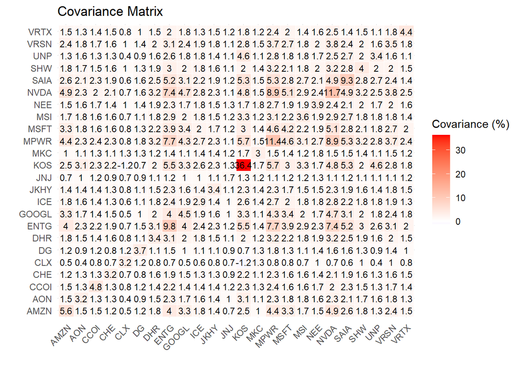

```r
# Plot covariance matrix
cov_mat <- cov(ret_xts)
melted_cov_mat <- melt(cov_mat)
cov_plot <- ggplot(data = melted_cov_mat, aes(x = Var1, y = Var2, fill = value)) +
  geom_tile(color = "white") +
  scale_fill_gradient2(low = "blue", high = "red", mid = "white",
                       midpoint = 0, limit = c(min(melted_cov_mat$value), max(melted_cov_mat$value)),
                       name="Covariance (%)") +
  geom_text(aes(label = round(value, 1)), color = "black", size = 3) +
  theme_minimal() +
  theme(axis.text.x = element_text(angle = 45, vjust = 1, hjust = 1)) +
  labs(title = "Covariance Matrix", x = "", y = "")

cov_plot
```

```r
#Calculate mean daily return
mean_ret <- colMeans(ret_xts, na.rm = TRUE)
```

## C) Explain what the efficient frontier means. Which portfolio would you invest in and why?

It represents a set of optimal portfolios that offer the highest expected return for a given level of risk or the lowest risk for a given level of expected return.

I am going to conduct an analysis below to identify my choice of portfolio using sortino ratio. Please note that return value and sortino ratio needs to be annualized if you are comparing against annualized bench mark. (2 is the desired sortion ratio in annual basisEE)

## D) Add short-sale constraints and plot the constrained efficient frontier together with the one from b). Explain any differences you see

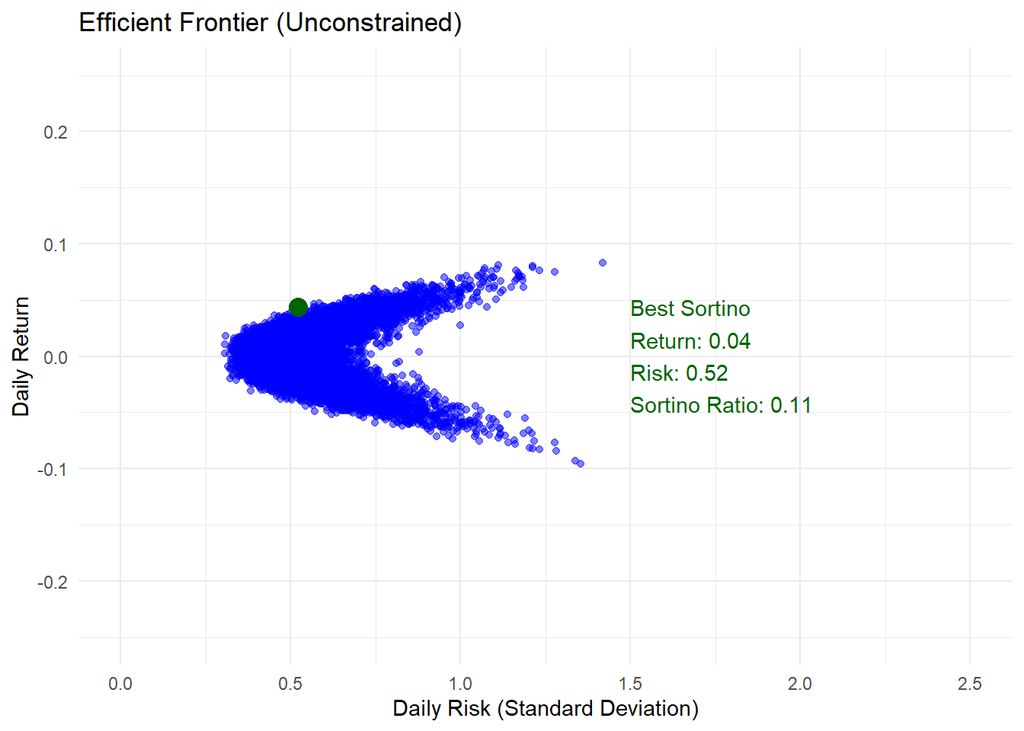

```r
## set risk-free rate
getSymbols(Symbols = "DGS3MO", src = "FRED", auto.assign = FALSE) -> treasuries
risk_free_rate <- as.numeric(last(treasuries))
risk_free_rate <- (1 + risk_free_rate)^(1/360) - 1 #Converted the rate from annualized rate to daily rate
risk_free_rate <- risk_free_rate
## Set seed for reproducibility
set.seed(123)
# Generate random weights (unconstrained: weights between -1 and 1)
all_weights_unconstrained <- t(replicate(10000, generate_random_weights(length(tickers), allow_short = TRUE)))

# Convert to data table (unconstrained)
all_weights_unconstrained <- data.table(all_weights_unconstrained)
colnames(all_weights_unconstrained) <- tickers

total_run <- length(tickers) * 10000
random_numbers <- runif(total_run, min = -1, max = 1)
all_weights_unconstrained <- matrix(random_numbers, nrow = 10000, ncol = length(tickers))

# Normalize the weights to sum to 1 (unconstrained)
for (i in 1:10000) {
  all_weights_unconstrained[i, ] <- all_weights_unconstrained[i, ] / sum(abs(all_weights_unconstrained[i, ]))
}

# Convert to data table (unconstrained) and check all the weights are equaling to 1
all_weights_unconstrained <- data.table(all_weights_unconstrained)
colnames(all_weights_unconstrained) <- tickers
all_weights_unconstrained[, row_sum := rowSums(.SD), .SDcols = tickers] #Check portfolio weights total to 1
all_weights_unconstrained[,row_sum := NULL]


# Calculate portfolio risk and returns (unconstrained)
portfolio_risk_unconstrained <- apply(all_weights_unconstrained, 1, function(weights) sqrt(t(weights) %*% cov_mat %*% weights))
portfolio_returns_unconstrained <- apply(all_weights_unconstrained, 1, function(weights) sum(weights * mean_ret))

# Create data table with portfolio risk, returns, and Sharpe ratio (unconstrained)
portfolio_df_unconstrained <- data.table(portfolio_risk_unconstrained, portfolio_returns_unconstrained)

# Generate random weights (constrained: no short-selling)
random_numbers_constrained <- runif(total_run)
all_weights_constrained <- matrix(random_numbers_constrained, nrow = 10000, ncol = length(tickers))

# Normalize the weights to sum to 1 (constrained)
for (i in 1:10000) {
  all_weights_constrained[i, ] <- all_weights_constrained[i, ] / sum(all_weights_constrained[i, ])
}

# Convert to data table (constrained)
all_weights_constrained <- data.table(all_weights_constrained)
colnames(all_weights_constrained) <- tickers

# Calculate portfolio risk and returns (constrained)
portfolio_risk_constrained <- apply(all_weights_constrained, 1, function(weights) sqrt(t(weights) %*% cov_mat %*% weights))
portfolio_returns_constrained <- apply(all_weights_constrained, 1, function(weights) sum(weights * mean_ret))

portfolio_downside_risk_unconstrained <- apply(all_weights_unconstrained, 1, function(weights) {
  portfolio_returns <- ret_xts %*% weights
  downside_deviation(portfolio_returns)
})

# Create data table with portfolio risk, returns, and ratios (unconstrained)
portfolio_df_unconstrained <- data.table(portfolio_risk_unconstrained, portfolio_returns_unconstrained)
portfolio_df_unconstrained[, sortino_ratio := (portfolio_returns_unconstrained - risk_free_rate) / portfolio_downside_risk_unconstrained]

# Find the portfolios with the highest Sharpe, Sortino, and Treynor ratios (unconstrained)
best_sortino_unconstrained <- portfolio_df_unconstrained[which.max(sortino_ratio)]

# Generate random weights for constrained (no short-selling) portfolios
all_weights_constrained <- t(replicate(10000, generate_random_weights(length(tickers), allow_short = FALSE)))

# Convert to data table (constrained)
all_weights_constrained <- data.table(all_weights_constrained)
colnames(all_weights_constrained) <- tickers

# Calculate portfolio risk and returns (constrained)
portfolio_risk_constrained <- apply(all_weights_constrained, 1, function(weights) sqrt(t(weights) %*% cov_mat %*% weights))
portfolio_returns_constrained <- apply(all_weights_constrained, 1, function(weights) sum(weights * mean_ret))

# Calculate downside deviation for Sortino ratio
portfolio_downside_risk_constrained <- apply(all_weights_constrained, 1, function(weights) {
  portfolio_returns <- ret_xts %*% weights
  downside_deviation(portfolio_returns)
})

# Create data table with portfolio risk, returns, and ratios (constrained)
portfolio_df_constrained <- data.table(portfolio_risk_constrained, portfolio_returns_constrained)
portfolio_df_constrained[, sortino_ratio := (portfolio_returns_constrained - risk_free_rate) / portfolio_downside_risk_constrained]

# Find the portfolios with the highest Sharpe, Sortino, and Treynor ratios (constrained)
best_sortino_constrained <- portfolio_df_constrained[which.max(sortino_ratio)]

# Plot the efficient frontiers for unconstrained portfolios
plot_unconstrained <- ggplot(portfolio_df_unconstrained, aes(x = portfolio_risk_unconstrained, y = portfolio_returns_unconstrained)) +
  geom_point(color = "blue", alpha = 0.5) +
  geom_point(aes(x = best_sortino_unconstrained$portfolio_risk_unconstrained, y = best_sortino_unconstrained$portfolio_returns_unconstrained), color = "darkgreen", size = 4) +
  labs(title = "Efficient Frontier (Unconstrained)",
       x = "Daily Risk (Standard Deviation)",
       y = "Daily Return") +
  theme_minimal() +
    ylim(-0.25,0.25) +
    xlim(0,2.5) +
  annotate("text", x = 1.5, y = -0.05,
           label = paste0("Best Sortino\nReturn: ", round(best_sortino_unconstrained$portfolio_returns_unconstrained, 2),
                          "\nRisk: ", round(best_sortino_unconstrained$portfolio_risk_unconstrained, 2),
                           "\nSortino Ratio: ", round(best_sortino_unconstrained$sortino_ratio, 2)),
           hjust = 0, vjust = 0, color = "darkgreen")

# Plot the efficient frontiers for constrained portfolios
plot_constrained <- ggplot(portfolio_df_constrained, aes(x = portfolio_risk_constrained, y = portfolio_returns_constrained)) +
  geom_point(color = "blue", alpha = 0.5) +
  geom_point(aes(x = best_sortino_constrained$portfolio_risk_constrained, y = best_sortino_constrained$portfolio_returns_constrained), color = "darkgreen", size = 4) +
  labs(title = "Efficient Frontier (Constrained)",
       x = "Daily Risk (Standard Deviation)",
       y = "Daily Return") +
  theme_minimal() +
    ylim(-0.25, 0.25) +
    xlim(0,2.5) +
  annotate("text", x =2.0 , y = -0.05,
           label = paste0("Best Sortino\nReturn: ", round(best_sortino_constrained$portfolio_returns_constrained, 2),
                          "\nRisk: ", round(best_sortino_constrained$portfolio_risk_constrained, 2),
                          "\nSortino Ratio: ", round(best_sortino_constrained$sortino_ratio, 2)),
           hjust = 0, vjust = 0, color = "darkgreen")

plot_unconstrained
```

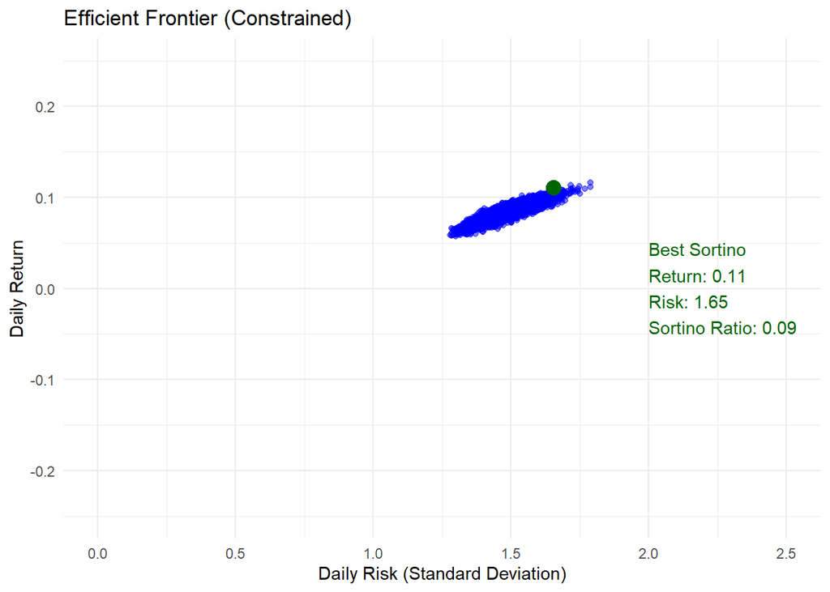

[output not shown]

[output not shown]

```r
plot_constrained
```

## E) If you wanted to invest in 200 equities, explain any difficulties in computing the covariance matrix and how these can be overcome.

One of the issues with scaling this analysis to a larger list of tickers is complexity and the computational toll to calculate the covariance for all the pair variations for 200 tickers. In order to combat this, I would reduce the number of dimensions, such as PCA or factor models. Also, it would be worthwhile to use parallel computing to speed up the computation.